# Methylation of P/PIR of DNMT KO upregulated genes

Reviewer’s comment:

For example, the authors mention that “Dnmt TKO resulted in more upregulated than downregulated genes in EpiLC, consistent with a role in gene repression”. How many of the upregulated genes are associated with regulatory elements (promoter or enhancers) that actually get methylated during wildtype ESC-EpiLC transition, thereby implying direct responses in mutants.

- Identify P/PIR of DNMT KO upregulated genes
- plot methylation DNMT ES WT to DNMT Epi WT

Defining source, libraries and options

```r
source("cluster_analysis_functions.R")
options(scipen = 0)
```

Plotting options

Importing datasets

The marks table was created for capped and uncapped values (the latter only to be used for colouring the umaps). Linkings of marks to clusters happens in the script series umap_20_01_20_unccapped_marks and was exported from there.

```r
#read_tsv("../data/pluripotency_exit_RNA_Epi_and_EB_log2RPKM.txt") -> expression_import
read_tsv("../data/Annotated Probe Report for DE DNMT Epi WT vs KO no MTC.txt") -> DNMT_KO_Epi_upregulated_import
```

```r
clusters_uncapped_marks %>%
  rename_with(~gsub("H3K27Ac", "H3K27ac",.)) -> marks
colnames(marks)
```

```
  [1] "interaction_ID"            "V1"                        "V2"                        "bait_ID"
  [5] "oe_ID"                     "bait_gene"                 "oe_gene"                   "CHiC_DNMT_KO_Epi"
  [9] "CHiC_DNMT_KO_ES"           "CHiC_DNMT_WT_Epi"          "CHiC_DNMT_WT_ES"           "CHiC_TET_KO_Epi"
 [13] "CHiC_TET_KO_ES"            "CHiC_TET_WT_Epi"           "CHiC_TET_WT_ES"            "bait_mC_DNMT_WT_ES"
 [17] "bait_mC_DNMT_WT_Epi"       "bait_mC_TET_WT_ES"         "bait_mC_TET_WT_Epi"        "bait_mC_TET_KO_ES"
 [21] "bait_mC_TET_KO_Epi"        "oe_mC_DNMT_WT_ES"          "oe_mC_DNMT_WT_Epi"         "oe_mC_TET_WT_ES"
 [25] "oe_mC_TET_WT_Epi"          "oe_mC_TET_KO_ES"           "oe_mC_TET_KO_Epi"          "bait_hmC_TET_WT_ES"
 [29] "bait_hmC_TET_WT_Epi"       "bait_hmC_DNMT_WT_Epi"      "bait_ATAC_DNMT_KO_Epi"     "bait_ATAC_DNMT_KO_ES"
 [33] "bait_ATAC_DNMT_WT_Epi"     "bait_ATAC_DNMT_WT_ES"      "bait_ATAC_TET_KO_Epi"      "bait_ATAC_TET_KO_ES"
 [37] "bait_ATAC_TET_WT_Epi"      "bait_ATAC_TET_WT_ES"       "bait_CTCF_DNMT_KO_Epi"     "bait_CTCF_DNMT_KO_ES"
 [41] "bait_CTCF_DNMT_WT_Epi"     "bait_CTCF_DNMT_WT_ES"      "bait_CTCF_TET_KO_Epi"      "bait_CTCF_TET_KO_ES"
 [45] "bait_CTCF_TET_WT_Epi"      "bait_CTCF_TET_WT_ES"       "bait_H3K27ac_DNMT_KO_Epi"  "bait_H3K27ac_DNMT_KO_ES"
 [49] "bait_H3K27ac_DNMT_WT_Epi"  "bait_H3K27ac_DNMT_WT_ES"   "bait_H3K27ac_TET_KO_Epi"   "bait_H3K27ac_TET_KO_ES"
 [53] "bait_H3K27ac_TET_WT_Epi"   "bait_H3K27ac_TET_WT_ES"    "bait_H3K27me3_DNMT_KO_Epi" "bait_H3K27me3_DNMT_KO_ES"
 [57] "bait_H3K27me3_DNMT_WT_Epi" "bait_H3K27me3_DNMT_WT_ES"  "bait_H3K27me3_TET_KO_Epi"  "bait_H3K27me3_TET_KO_ES"
```

[output cut: 22 more lines]

Getting the gene names for the DNMT KO Epi upregulated genes

| Probe | Chromosome | Start | End | Probe Strand | Feature | ID | Description | Feature Strand | Type | Feature Orientation | Distance | DNMT_WT_ES | DNMT_WT_Epi_2 | DNMT_KO_ES | DNMT_KO_Epi_2 | TET_WT_ES | TET_WT_Epi_2 | TET_KO_ES | TET_KO_Epi_2 |
| --- | --- | --- | --- | --- | --- | --- | --- | --- | --- | --- | --- | --- | --- | --- | --- | --- | --- | --- | --- |
| Sgk3 | 1 | 9798107 | 9900845 | + | Sgk3 | ENSMUSG00000025915 | serum/glucocorticoid regulated kinase 3 [Source:MGI Symbol;Acc:MGI:2182368] | + | gene | Name match | 0 | 5.067684650 | 3.30189419 | 4.975014210 | 4.36804247 | 3.85247231 | 3.25669765 | 4.04510736 | 3.824402571 |
| Tcf24 | 1 | 9960163 | 9967932 | - | Tcf24 | ENSMUSG00000099032 | transcription factor 24 [Source:MGI Symbol;Acc:MGI:3780500] | - | gene | Name match | 0 | 2.588345528 | 1.91564333 | 3.348397970 | 3.84160137 | 1.55103338 | 2.20476747 | 1.42212868 | 2.688986778 |
| Arfgef1 | 1 | 10137571 | 10232670 | - | Arfgef1 | ENSMUSG00000067851 | ADP-ribosylation factor guanine nucleotide- exchange factor 1(brefeldin A-inhibited) [Source:MGI Symbol;Acc:MGI:2442988] | - | gene | Name match | 0 | 6.983484268 | 6.93673897 | 7.293394089 | 7.39630079 | 6.50988436 | 5.76246834 | 6.57369566 | 5.544677734 |
| Slco5a1 | 1 | 12866549 | 12992650 | - | Slco5a1 | ENSMUSG00000025938 | solute carrier organic anion transporter family, member 5A1 [Source:MGI Symbol;Acc:MGI:2443431] | - | gene | Name match | 0 | 2.558492661 | 1.41743600 | 2.397248983 | 2.56374478 | 1.83855951 | 0.84896070 | 2.54211998 | 1.064410925 |
| Stau2 | 1 | 16228674 | 16520112 | - | Stau2 | ENSMUSG00000025920 | staufen double-stranded RNA binding protein 2 [Source:MGI Symbol;Acc:MGI:1352508] | - | gene | Name match | 0 | 3.792227268 | 4.43863726 | 4.263513565 | 5.12738466 | 2.86208534 | 3.96263123 | 3.86596584 | 3.657947540 |
| Rims1 | 1 | 22286251 | 22805994 | - | Rims1 | ENSMUSG00000041670 | regulating synaptic membrane exocytosis 1 [Source:MGI Symbol;Acc:MGI:2152971] | - | gene | Name match | 0 | 3.167971611 | 0.14384826 | 3.522045135 | 2.12735176 | -2.17956662 | -2.69633889 | 1.45623636 | -0.376231760 |
| Smap1 | 1 | 23844846 | 23922317 | - | Smap1 | ENSMUSG00000026155 | small ArfGAP 1 [Source:MGI Symbol;Acc:MGI:2138261] | - | gene | Name match | 0 | 6.882451057 | 6.23574638 | 7.154790401 | 6.67411184 | 6.08500147 | 5.36408043 | 6.57274580 | 5.080521107 |
| Fam135a | 1 | 24011093 | 24100341 | - | Fam135a | ENSMUSG00000026153 | family with sequence similarity 135, member A [Source:MGI Symbol;Acc:MGI:1915437] | - | gene | Name match | 0 | 4.325953484 | 4.98607492 | 4.755684376 | 5.92170668 | 4.35063887 | 5.32907534 | 5.06393957 | 5.175964832 |
| Vwa3b | 1 | 37026596 | 37187613 | + | Vwa3b | ENSMUSG00000050122 | von Willebrand factor A domain containing 3B [Source:MGI Symbol;Acc:MGI:1918103] | + | gene | Name match | 0 | 5.052309036 | 4.58825874 | 4.948427200 | 3.75973892 | 3.03995252 | 4.01685858 | 3.57012916 | 3.405833960 |
| Gm28321 | 1 | 50815375 | 50817701 | + | Gm28321 | ENSMUSG00000100816 | predicted gene 28321 [Source:MGI Symbol;Acc:MGI:5579027] | + | gene | Name match | 0 | -1.585132837 | -0.53382343 | -1.605788708 | 1.64268053 | -3.63386655 | -1.97303069 | -3.63469481 | -2.257517099 |

[output cut: 990 more lines]

Filtering the marks table for methylation of elements associated with the upregulated genes

| interaction_ID | bait_gene | oe_gene | cluster_ID | bait_mC_DNMT_WT_ES | bait_mC_DNMT_WT_Epi | oe_mC_DNMT_WT_ES | oe_mC_DNMT_WT_Epi |
| --- | --- | --- | --- | --- | --- | --- | --- |
| 1_9796017_9800151...1_9898321_9899102 | Sgk3 | NA | cluster1 | 1.017595 | 15.0867 | 2.901355 | 60.40632 |
| 1_9796017_9800151...1_9933239_9935385 | Sgk3 | NA | cluster1 | 1.017595 | 15.0867 | 2.764230 | 59.76242 |
| 1_9796017_9800151...1_9976012_9979294 | Sgk3 | NA | cluster1 | 1.017595 | 15.0867 | 2.586502 | 54.25471 |
| 1_9796017_9800151...1_9982928_9984242 | Sgk3 | NA | cluster1 | 1.017595 | 15.0867 | 4.398190 | 65.52654 |
| 1_9796017_9800151...1_9984418_9988306 | Sgk3 | NA | cluster1 | 1.017595 | 15.0867 | 3.000852 | 71.38505 |
| 1_9796017_9800151...1_9989103_9991978 | Sgk3 | NA | cluster1 | 1.017595 | 15.0867 | 5.071321 | 70.37342 |

Since we are really only looking at clusters 2, 12, 16, 17, maybe we should filter to only include those clusters in the analysis

| interaction_ID | bait_gene | oe_gene | cluster_ID | fragment | genotype | stage | methylation |
| --- | --- | --- | --- | --- | --- | --- | --- |
| 1_9796017_9800151...1_9999054_9999434 | Sgk3 | NA | cluster12 | P | WT | ES | 1.0175946 |
| 1_9796017_9800151...1_9999054_9999434 | Sgk3 | NA | cluster12 | P | WT | Epi | 15.0866960 |
| 1_9796017_9800151...1_9999054_9999434 | Sgk3 | NA | cluster12 | PIR | WT | ES | 5.0627660 |
| 1_9796017_9800151...1_9999054_9999434 | Sgk3 | NA | cluster12 | PIR | WT | Epi | 61.2262611 |
| 1_57766534_57777666...1_57890461_57892120 | Spats2l | NA | cluster16 | P | WT | ES | 1.3028481 |
| 1_57766534_57777666...1_57890461_57892120 | Spats2l | NA | cluster16 | P | WT | Epi | 29.3744092 |
| 1_57766534_57777666...1_57890461_57892120 | Spats2l | NA | cluster16 | PIR | WT | ES | 5.1357312 |
| 1_57766534_57777666...1_57890461_57892120 | Spats2l | NA | cluster16 | PIR | WT | Epi | 55.1287956 |
| 1_57766534_57777666...1_57955818_57956100 | Spats2l | NA | cluster12 | P | WT | ES | 1.3028481 |
| 1_57766534_57777666...1_57955818_57956100 | Spats2l | NA | cluster12 | P | WT | Epi | 29.3744092 |

[output cut: 990 more lines]

Plotting methylation across fragment, genotype and stage

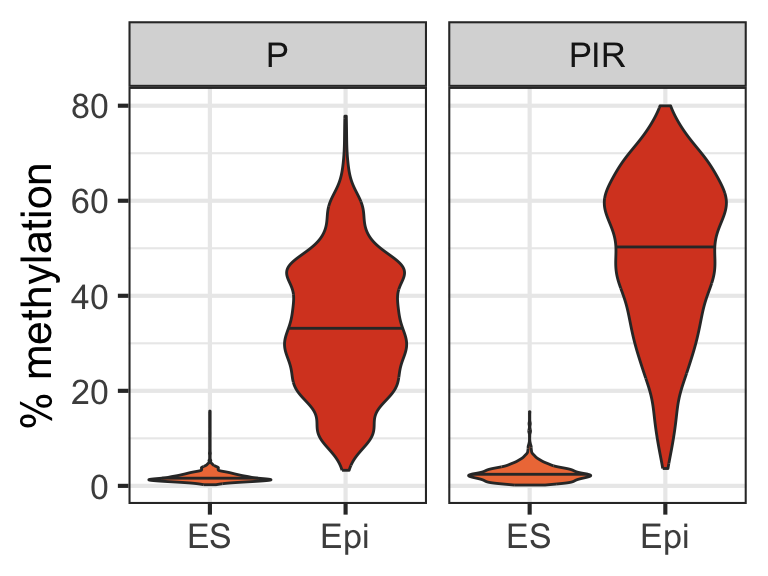

```r
methylation_included_clusters %>%
  ggplot(aes(stage, methylation, fill = stage)) +
  geom_violin(draw_quantiles = 0.5, scale = "width") +
  scale_fill_manual(values = c(ES_colour, Epi_colour)) +
  facet_grid(cols = vars(fragment)) +
  ylab("% methylation") +
  theme(legend.position = "none", axis.title.x = element_blank()) -> methylation_upregulated_elements_violins


  methylation_upregulated_elements_violins
```

Exporting

```r
ggsave("methylation_DNMT_KO_up_genes_violins.png", methylation_upregulated_elements_violins, width = 4, height = 3)
```

Note by: I haven’t deduplicated the fragments, so if a promoter appears in more than one interaction, it will be plotted several times. I reasoned that this is ok as it represents different PIRs.